# Mauritanie - Insécurité alimentaire

1. Import des librairies nécessaires

```r
#import des libraries
library(foreign)
library(cramer)
library(questionr)
```

```r
library(ggplot2)
library(dplyr)
library(tidyr)
library(hrbrthemes)
library(viridis)
```

2. Import des données

```r
fsms_juin_2015 = read.spss('C:/Users/Mariem/Documents/1. Statistics & Data science/5. Data for good/Mauritania FSMS data-20210422T155253Z-001/Mauritania FSMS data/2015/Juin/Données_FSMS_juin_15.sav', use.value.labels = TRUE, to.data.frame = TRUE)
```

```
## re-encoding from CP1252
```

```r
fsms_decembre_2015 = read.spss('C:/Users/Mariem/Documents/1. Statistics & Data science/5. Data for good/Mauritania FSMS data-20210422T155253Z-001/Mauritania FSMS data/2015/Decembre/Données FSMS Jan16_18_02.sav', use.value.labels = TRUE, to.data.frame = TRUE)
```

```
## re-encoding from CP1252
```

```r
wfp_food_prices_mauritania <- read.csv("~/1. Statistics & Data science/5. Data for good/wfp_food_prices_mauritania.csv", header=TRUE, comment.char="#")
aggregated_match_for_FSMS_files_with_yields_with_price <- read.csv("~/1. Statistics & Data science/5. Data for good/aggregated_match_for_FSMS_files_with_yields_with_price.csv", header=TRUE)
```

3. Analyse univariée

3.1. Strate Juin 2015

```r
#STRATE
table(fsms_juin_2015$STRATE)
```

```
##
##                           Hodh Echarghi                           Hodh El Garbi
##                                     288                                     288
##                                  Assaba                                  Gorgol
##                                     288                                     282
##                                  Brakna                                  Trarza
##                                     289                                     286
## Nord (Adrar, Inchiri, Nouadhibou,Tiris)                                  Tagant
##                                     455                                     287
##                               Guidimaka                        Nouakchott Ouest
##                                     286                                     221
##                          Nouakchott Sud                         Nouakchott Nord
##                                     257                                     246
```

```r
table(fsms_juin_2015$STRATE)/nrow(fsms_juin_2015)*100
```

```
##
##                           Hodh Echarghi                           Hodh El Garbi
##                                8.292542                                8.292542
##                                  Assaba                                  Gorgol
##                                8.292542                                8.119781
##                                  Brakna                                  Trarza
##                                8.321336                                8.234955
## Nord (Adrar, Inchiri, Nouadhibou,Tiris)                                  Tagant
##                               13.101065                                8.263749
##                               Guidimaka                        Nouakchott Ouest
##                                8.234955                                6.363375
##                          Nouakchott Sud                         Nouakchott Nord
##                                7.399942                                7.083213
```

```r
#STRATE1
table(fsms_juin_2015$STRATE1)
```

```
##
##                Hodh Echarghi                Hodh El Garbi
##                          288                          288
##                       Assaba                       Gorgol
##                          288                          282
##                       Brakna                       Trarza
##                          289                          286
## Nord (Adrar, Inchiri, Tiris)           Dakhlet-Nouadhibou
##                          285                          170
##                       Tagant                    Guidimaka
##                          287                          286
##             Nouakchott Ouest               Nouakchott Sud
##                          221                          257
##              Nouakchott Nord
##                          246
```

```r
table(fsms_juin_2015$STRATE1)/nrow(fsms_juin_2015)*100
```

```
##
##                Hodh Echarghi                Hodh El Garbi
##                     8.292542                     8.292542
##                       Assaba                       Gorgol
##                     8.292542                     8.119781
##                       Brakna                       Trarza
##                     8.321336                     8.234955
## Nord (Adrar, Inchiri, Tiris)           Dakhlet-Nouadhibou
##                     8.206162                     4.894904
##                       Tagant                    Guidimaka
##                     8.263749                     8.234955
##             Nouakchott Ouest               Nouakchott Sud
##                     6.363375                     7.399942
##              Nouakchott Nord
##                     7.083213
```

Décembre 2015

```r
#STRATE
table(fsms_decembre_2015$STRATE)
```

```
##
##      Hodh_Echargui     Hodh_El_Gharbi             Assaba             Gorgol
##                303                298                300                300
##             Brakna             Trarza              Adrar Dakhlet_Nouadhibou
##                294                280                137                301
##             Tagant         Guidimakha      Inchiri-Tiris         Nouakchott
##                299                298                162                749
```

```r
table(fsms_decembre_2015$STRATE)/nrow(fsms_decembre_2015)*100
```

```
##
##      Hodh_Echargui     Hodh_El_Gharbi             Assaba             Gorgol
##           8.142972           8.008600           8.062349           8.062349
##             Brakna             Trarza              Adrar Dakhlet_Nouadhibou
##           7.901102           7.524859           3.681806           8.089223
##             Tagant         Guidimakha      Inchiri-Tiris         Nouakchott
##           8.035474           8.008600           4.353668          20.128998
```

```r
#STRATE1
table(fsms_decembre_2015$STRATE1)
```

```
## < table of extent 0 >
```

```r
table(fsms_decembre_2015$STRATE1)/nrow(fsms_decembre_2015)*100
```

```
## numeric(0)
```

3.2. Wilaya Juin 2015

```r
#wilaya
table(fsms_juin_2015$wilaya)
```

```
##
##      Hodh Echarghi       Hodh El Garbi              Assaba              Gorgol
##                 288                 288                 288                 282
##             Brakna              Trarza               Adrar  Dakhlet-Nouadhibou
##                 289                 286                 222                 170
##             Tagant           Guidimaka       Tiris Zemmour             Inchiri
##                 287                 286                   0                  63
##         Nouakchott
##                 724
```

```r
table(fsms_juin_2015$wilaya)/nrow(fsms_juin_2015)*100
```

```
##
##      Hodh Echarghi       Hodh El Garbi              Assaba              Gorgol
##            8.292542            8.292542            8.292542            8.119781
##             Brakna              Trarza               Adrar  Dakhlet-Nouadhibou
##            8.321336            8.234955            6.392168            4.894904
##             Tagant           Guidimaka       Tiris Zemmour             Inchiri
##            8.263749            8.234955            0.000000            1.813994
##         Nouakchott
##           20.846530
```

Décembre 2015

```r
#wilaya
table(fsms_decembre_2015$wilaya)
```

```
##
##      Hodh_Echargui     Hodh_El_Gharbi             Assaba             Gorgol
##                303                298                300                300
##             Brakna             Trarza              Adrar Dakhlet_Nouadhibou
##                294                280                137                301
##             Tagant         Guidimakha      Tiris_Zemmour            Inchiri
##                299                298                119                 43
##   Nouakchott Ouest     Nouakchott Sud    Nouakchott Nord
##                247                249                253
```

```r
table(fsms_decembre_2015$wilaya)/nrow(fsms_decembre_2015)*100
```

```
##
##      Hodh_Echargui     Hodh_El_Gharbi             Assaba             Gorgol
##           8.142972           8.008600           8.062349           8.062349
##             Brakna             Trarza              Adrar Dakhlet_Nouadhibou
##           7.901102           7.524859           3.681806           8.089223
##             Tagant         Guidimakha      Tiris_Zemmour            Inchiri
##           8.035474           8.008600           3.198065           1.155603
##   Nouakchott Ouest     Nouakchott Sud    Nouakchott Nord
##           6.638001           6.691750           6.799248
```

3.3. Moughataa Juin 2015

```r
#moughataa
table(fsms_juin_2015$moughataa)
```

```
##
##        Amourj   Bassikounou     Djiguenni          Nema       Oualata
##            64            16            64            64             0
##     Tembedgha          Dhar         Aioun      Koubenni    Tamchekett
##            80             0           128            96            32
##       Tintane     Barkeiwel      Boumdeid        Guerou      Kankossa
##            32            48            16           128            96
##         Kiffa         Kaedi       Maghama         MBout       Monguel
##             0            80            63           109            30
##          Aleg        Bababe         Boghe Maghta_Lahjar        MBagne
##           161             0            80             0            48
##    Boutilimit   Keur_Macène      Mederdra     Ouad_Naga          RKiz
##            64            48            16            16            46
##         Rosso        Awjeft          Atar    Chinguitti       Ouadane
##            96            48           158             0            16
##    Nouadhibou        Chami_     Moudjeria        Tichit      Tidjigja
##           170             0           111            16           160
##    Ould_Yenge     Seilibaby  Biroumghrein      FDeireck      Zoueirat
##           110           176             0             0             0
##       Akjoujt        Arafat      Dar Naim       El Mina          Ksar
##            63           128            63            48           112
##         Riyad        Sebkha Tevragh Zeina       Teyaret    Toujounine
##            81            96            13            72           111
```

```r
table(fsms_juin_2015$moughataa)/nrow(fsms_juin_2015)*100
```

```
##
##        Amourj   Bassikounou     Djiguenni          Nema       Oualata
##     1.8427872     0.4606968     1.8427872     1.8427872     0.0000000
##     Tembedgha          Dhar         Aioun      Koubenni    Tamchekett
##     2.3034840     0.0000000     3.6855744     2.7641808     0.9213936
##       Tintane     Barkeiwel      Boumdeid        Guerou      Kankossa
##     0.9213936     1.3820904     0.4606968     3.6855744     2.7641808
##         Kiffa         Kaedi       Maghama         MBout       Monguel
##     0.0000000     2.3034840     1.8139937     3.1384970     0.8638065
##          Aleg        Bababe         Boghe Maghta_Lahjar        MBagne
##     4.6357616     0.0000000     2.3034840     0.0000000     1.3820904
##    Boutilimit   Keur_Macène      Mederdra     Ouad_Naga          RKiz
##     1.8427872     1.3820904     0.4606968     0.4606968     1.3245033
##         Rosso        Awjeft          Atar    Chinguitti       Ouadane
##     2.7641808     1.3820904     4.5493809     0.0000000     0.4606968
##    Nouadhibou        Chami_     Moudjeria        Tichit      Tidjigja
##     4.8949035     0.0000000     3.1960841     0.4606968     4.6069680
##    Ould_Yenge     Seilibaby  Biroumghrein      FDeireck      Zoueirat
##     3.1672905     5.0676648     0.0000000     0.0000000     0.0000000
##       Akjoujt        Arafat      Dar Naim       El Mina          Ksar
##     1.8139937     3.6855744     1.8139937     1.3820904     3.2248776
##         Riyad        Sebkha Tevragh Zeina       Teyaret    Toujounine
##     2.3322776     2.7641808     0.3743162     2.0731356     3.1960841
```

Décembre 2015

```r
#moughataa
table(fsms_decembre_2015$moughataa)
```

```
##
##        Amourj   Bassikounou     Djiguenni          Nema       Oualata
##            78             0            61            90             0
##     Tembedgha          Dhar         Aioun      Koubenni    Tamchekett
##            75             0            58            90            45
##       Tintane     Barkeiwel      Boumdeid        Guerou      Kankossa
##           105            75            15            45            75
##         Kiffa         Kaedi       Maghama         MBout       Monguel
##            90           105            60            90            45
##          Aleg        Bababe         Boghe Maghta_Lahjar        MBagne
##            75            45            84            45            45
##    Boutilimit   Keur_Macene      Mederdra     Ouad_Naga          RKiz
##            54            30            21            34            68
##         Rosso        Awjeft          Atar    Chinguitti       Ouadane
##            73            30            92            15             0
##    Nouadhibou        Chami_     Moudjeria        Tichit      Tidjigja
##           286            15           165            15           119
##    Ould_Yenge     Seilibaby  Biroumghrein      FDeireck      Zoueirat
##            94           204            14             0           105
##       Akjoujt          Ksar Tevragh Zeina        Sebkha       El Mina
##            43            79            75            92            77
##        Arafat         Riyad       Teyaret    Toujounine      Dar Naim
##            94            78            45           108           100
```

```r
table(fsms_decembre_2015$moughataa)/nrow(fsms_decembre_2015)*100
```

```
##
##        Amourj   Bassikounou     Djiguenni          Nema       Oualata
##     2.0962107     0.0000000     1.6393443     2.4187046     0.0000000
##     Tembedgha          Dhar         Aioun      Koubenni    Tamchekett
##     2.0155872     0.0000000     1.5587208     2.4187046     1.2093523
##       Tintane     Barkeiwel      Boumdeid        Guerou      Kankossa
##     2.8218221     2.0155872     0.4031174     1.2093523     2.0155872
##         Kiffa         Kaedi       Maghama         MBout       Monguel
##     2.4187046     2.8218221     1.6124698     2.4187046     1.2093523
##          Aleg        Bababe         Boghe Maghta_Lahjar        MBagne
##     2.0155872     1.2093523     2.2574577     1.2093523     1.2093523
##    Boutilimit   Keur_Macene      Mederdra     Ouad_Naga          RKiz
##     1.4512228     0.8062349     0.5643644     0.9137329     1.8274657
##         Rosso        Awjeft          Atar    Chinguitti       Ouadane
##     1.9618382     0.8062349     2.4724536     0.4031174     0.0000000
##    Nouadhibou        Chami_     Moudjeria        Tichit      Tidjigja
##     7.6861059     0.4031174     4.4342919     0.4031174     3.1980650
##    Ould_Yenge     Seilibaby  Biroumghrein      FDeireck      Zoueirat
##     2.5262026     5.4823972     0.3762429     0.0000000     2.8218221
##       Akjoujt          Ksar Tevragh Zeina        Sebkha       El Mina
##     1.1556033     2.1230852     2.0155872     2.4724536     2.0693362
##        Arafat         Riyad       Teyaret    Toujounine      Dar Naim
##     2.5262026     2.0962107     1.2093523     2.9024456     2.6874496
```

3.4. Commune Juin 2015

```r
#commune
table(fsms_juin_2015$commune)
```

```
##
##                  Amourj             Adel_Bagrou               Bougadoum
##                      16                      16                      32
##                 Vessale               Djiguenni                 Mabrouk
##                      16                      16                      16
##         Ghlig_Ehel_Beye                    Nema              El_Mabrouk
##                      32                      16                      16
##               Beribavat               Agoueinit               Tembedgha
##                      16                      16                      16
##                   Touil               Bousteile             Hassi_MHadi
##                      16                      32                      16
##                   Aioun               Doueirare               Bennemane
##                      32                      16                      16
##                  Egjert             Oum_Lahyadh                Koubenni
##                      16                      48                      16
## Hassi_Ehel_Ahmed_Bechne                 Leghlig            Gogui_Zemmal
##                      16                      32                      32
##              Tamchekett          Guaet_Teidouma                 Tintane
##                      16                      16                      16
##                    Twil                 Gueller               El_Ghabra
##                      16                      16                      16
##              Boulahrath               Hsey_Tine                  Guerou
##                      16                      16                      80
##              Oudei_Jrid                  Kamour                Kankossa
##                      32                      16                      17
##                    Sani                 Blajmil                  Tenaha
##                      15                      16                      16
##                   Hamed                   Kaedi            Tifonde_Cive
##                      32                      64                      16
##                 Maghama                   Sagne           Wali_Djantang
##                      32                      16                      15
##                 Tikobra             NDjadjbenni             Foum_Gleita
##                      32                      16                      30
##                 Lahrach                  Bokhol         Azgueilem_Tiyab
##                      31                      16                      14
##                 Cheggar                    Male               Djellewar
##                      16                      97                      32
##                Bouhdide                   Boghe            Dar_El_Barka
##                      16                      48                      16
##               Wel_Birem                  MBagne          Debay_El_Hejaj
```

[output cut: 20 more lines]

```
##                      32                      32                      16
##                 Bouanze                  Lehraj               Seilibaby
##                      15                      15                      16
##                 Baydiam                 Gouraye                  Ghabou
##                      16                      32                      64
##                     Arr                    Ejar             Ould_Mbonny
##                      16                      16                      16
##                 Akjoujt                  Arafat                Dar Naim
##                      63                     128                      63
##                 El Mina                    Ksar                   Riyad
##                      48                     112                      81
##                  Sebkha           Tevragh Zeina                Teyarett
##                      96                      13                      72
##              Toujounine
##                     111
```

```r
table(fsms_juin_2015$commune)/nrow(fsms_juin_2015)*100
```

```
##
##                  Amourj             Adel_Bagrou               Bougadoum
##               0.4606968               0.4606968               0.9213936
##                 Vessale               Djiguenni                 Mabrouk
##               0.4606968               0.4606968               0.4606968
##         Ghlig_Ehel_Beye                    Nema              El_Mabrouk
##               0.9213936               0.4606968               0.4606968
##               Beribavat               Agoueinit               Tembedgha
##               0.4606968               0.4606968               0.4606968
##                   Touil               Bousteile             Hassi_MHadi
##               0.4606968               0.9213936               0.4606968
##                   Aioun               Doueirare               Bennemane
##               0.9213936               0.4606968               0.4606968
##                  Egjert             Oum_Lahyadh                Koubenni
##               0.4606968               1.3820904               0.4606968
## Hassi_Ehel_Ahmed_Bechne                 Leghlig            Gogui_Zemmal
##               0.4606968               0.9213936               0.9213936
##              Tamchekett          Guaet_Teidouma                 Tintane
##               0.4606968               0.4606968               0.4606968
##                    Twil                 Gueller               El_Ghabra
##               0.4606968               0.4606968               0.4606968
##              Boulahrath               Hsey_Tine                  Guerou
##               0.4606968               0.4606968               2.3034840
##              Oudei_Jrid                  Kamour                Kankossa
##               0.9213936               0.4606968               0.4894904
##                    Sani                 Blajmil                  Tenaha
##               0.4319033               0.4606968               0.4606968
##                   Hamed                   Kaedi            Tifonde_Cive
##               0.9213936               1.8427872               0.4606968
##                 Maghama                   Sagne           Wali_Djantang
##               0.9213936               0.4606968               0.4319033
##                 Tikobra             NDjadjbenni             Foum_Gleita
##               0.9213936               0.4606968               0.8638065
##                 Lahrach                  Bokhol         Azgueilem_Tiyab
##               0.8926001               0.4606968               0.4031097
##                 Cheggar                    Male               Djellewar
##               0.4606968               2.7929744               0.9213936
##                Bouhdide                   Boghe            Dar_El_Barka
##               0.4606968               1.3820904               0.4606968
##               Wel_Birem                  MBagne          Debay_El_Hejaj
```

[output cut: 20 more lines]

```
##               0.9213936               0.9213936               0.4606968
##                 Bouanze                  Lehraj               Seilibaby
##               0.4319033               0.4319033               0.4606968
##                 Baydiam                 Gouraye                  Ghabou
##               0.4606968               0.9213936               1.8427872
##                     Arr                    Ejar             Ould_Mbonny
##               0.4606968               0.4606968               0.4606968
##                 Akjoujt                  Arafat                Dar Naim
##               1.8139937               3.6855744               1.8139937
##                 El Mina                    Ksar                   Riyad
##               1.3820904               3.2248776               2.3322776
##                  Sebkha           Tevragh Zeina                Teyarett
##               2.7641808               0.3743162               2.0731356
##              Toujounine
##               3.1960841
```

Décembre 2015

```r
#commune
table(fsms_decembre_2015$commune)
```

```
##
##   1101   1102   1103   1301   1302   1305   1401   1407   1408   1410   1601
##      1     34     43     31     15     15     30     15     30     15     30
##   1602   1604   1605   2101   2103   2107   2201   2202   2204   2205   2301
##     15     15     15     31     13     14     15     15     39     21     24
##   2304   2305   2401   2404   2406   2407   3101   3103   3104   3106   3107
##     14      7     63     15     15     12     15     15     15     15     15
##   3203   3301   3302   3304   3402   3403   3404   3405   3501   4101   4106
##     15     15     15     15     15     15     15     30     60     75     15
##   4107   4201   4202   4206   4207   4301   4302   4304   4306   4308   4401
##     15     15     15     15     15     15     15     15     30     15     15
##   4403   4405   5102   5103   5105   5201   5202   5203   5301   5303   5304
##     15     15     15     30     30     15     15     15     45     24     15
##   5401   5402   5403   5501   6101   6102   6106   6201   6203   6301   6401
##     15     15     15     41     40     14      4     15     15     21     15
##   6402   6501   6502   6503   6504   6601   7102   7104   7201   7203   7302
##     15     37      4     12     15     73     15     15     77     15     15
##   8101   8201   9102   9103   9202   9301   9302   9303   9304   9305  10101
##    286     15     90     75     15     44     11     29     30      5     16
##  10102  10103  10104  10106  10201  10202  10204  10205  10206  10207  10208
##     15     15     15     29     72     16     15     44     30     11     11
##  10210  11101  11301  12101  13101  13201  13301  14101  14201  14301  15101
##      9     14    105     43     78     52     92     77     94     78     45
##  15201  15301 130101
##    108    100      1
```

```r
table(fsms_decembre_2015$commune)/nrow(fsms_decembre_2015)*100
```

```
##
##      1101      1102      1103      1301      1302      1305      1401      1407
## 0.0268745 0.9137329 1.1556033 0.8331094 0.4031174 0.4031174 0.8062349 0.4031174
##      1408      1410      1601      1602      1604      1605      2101      2103
## 0.8062349 0.4031174 0.8062349 0.4031174 0.4031174 0.4031174 0.8331094 0.3493684
##      2107      2201      2202      2204      2205      2301      2304      2305
## 0.3762429 0.4031174 0.4031174 1.0481053 0.5643644 0.6449879 0.3762429 0.1881215
##      2401      2404      2406      2407      3101      3103      3104      3106
## 1.6930933 0.4031174 0.4031174 0.3224940 0.4031174 0.4031174 0.4031174 0.4031174
##      3107      3203      3301      3302      3304      3402      3403      3404
## 0.4031174 0.4031174 0.4031174 0.4031174 0.4031174 0.4031174 0.4031174 0.4031174
##      3405      3501      4101      4106      4107      4201      4202      4206
## 0.8062349 1.6124698 2.0155872 0.4031174 0.4031174 0.4031174 0.4031174 0.4031174
##      4207      4301      4302      4304      4306      4308      4401      4403
## 0.4031174 0.4031174 0.4031174 0.4031174 0.8062349 0.4031174 0.4031174 0.4031174
##      4405      5102      5103      5105      5201      5202      5203      5301
## 0.4031174 0.4031174 0.8062349 0.8062349 0.4031174 0.4031174 0.4031174 1.2093523
##      5303      5304      5401      5402      5403      5501      6101      6102
## 0.6449879 0.4031174 0.4031174 0.4031174 0.4031174 1.1018543 1.0749798 0.3762429
##      6106      6201      6203      6301      6401      6402      6501      6502
## 0.1074980 0.4031174 0.4031174 0.5643644 0.4031174 0.4031174 0.9943564 0.1074980
##      6503      6504      6601      7102      7104      7201      7203      7302
## 0.3224940 0.4031174 1.9618382 0.4031174 0.4031174 2.0693362 0.4031174 0.4031174
##      8101      8201      9102      9103      9202      9301      9302      9303
## 7.6861059 0.4031174 2.4187046 2.0155872 0.4031174 1.1824778 0.2956195 0.7793604
##      9304      9305     10101     10102     10103     10104     10106     10201
## 0.8062349 0.1343725 0.4299919 0.4031174 0.4031174 0.4031174 0.7793604 1.9349637
##     10202     10204     10205     10206     10207     10208     10210     11101
## 0.4299919 0.4031174 1.1824778 0.8062349 0.2956195 0.2956195 0.2418705 0.3762429
##     11301     12101     13101     13201     13301     14101     14201     14301
## 2.8218221 1.1556033 2.0962107 1.3974738 2.4724536 2.0693362 2.5262026 2.0962107
##     15101     15201     15301    130101
## 1.2093523 2.9024456 2.6874496 0.0268745
```

3.5. Milieu Juin 2015

```r
#MILIEU
table(fsms_juin_2015$MILIEU)
```

```
##
## Urbain  Rural
##   1562   1911
```

```r
table(fsms_juin_2015$MILIEU)/nrow(fsms_juin_2015)*100
```

```
##
##   Urbain    Rural
## 44.97553 55.02447
```

3.6. LHZ Juin 2015

```r
#LHZ
table(fsms_juin_2015$LHZ)
```

```
##
##           Nomadisme pastoral          Minière et pastoral
##                           64                           79
## Pastorale - oasiens et oueds            Littoral et Pêche
##                          302                          298
##        Pastorale et commerce       Transhumance pastorale
##                           96                           94
##                Agropastorale  La vallée du Fleuve Sénégal
##                         1035                          383
##           Cultures pluviales                   Nouakchott
##                          526                          596
```

```r
table(fsms_juin_2015$LHZ)/nrow(fsms_juin_2015)*100
```

```
##
##           Nomadisme pastoral          Minière et pastoral
##                     1.842787                     2.274690
## Pastorale - oasiens et oueds            Littoral et Pêche
##                     8.695652                     8.580478
##        Pastorale et commerce       Transhumance pastorale
##                     2.764181                     2.706594
##                Agropastorale  La vallée du Fleuve Sénégal
##                    29.801325                    11.027930
##           Cultures pluviales                   Nouakchott
##                    15.145407                    17.160956
```

3.7. LHG Juin 2015

```r
#LHG
table(fsms_juin_2015$LHG)
```

```
##
##                                                 Agriculture  (autoconsommation et vente)
##                                                                                        65
##                                                     Elevage  (autoconsommation et vente)
##                                                                                       547
##                                                       Pêche  (autoconsommation et vente)
##                                                                                        76
##                                           Chasse/cueillette  (autoconsommation et vente)
##                                                                                        31
##                                                              Ouvrier agricole/saisonnier
##                                                                                        93
##                                                       Commerce de produits agropastoraux
##                                                                                        71
##         Petit commerce (cartes téléphoniques, petits articles divers, cacahuètes,  etc.)
##                                                                                       247
## Journalier /Service du secteur informel (docker, coxer, ouvrier journalier, charretier…)
##                                                                                       582
##                                         Ouvrier/Artisan (ménuisier, maçon, électricien…)
##                                                                                       284
##                      Salarié du secteur informel (gardien, ménagère, conducteur de taxi)
##                                                                                       266
##                                      Fonctionnaire/salarié/Contractuel du secteur formel
##                                                                                       365
##                                                                         Pension/Retraite
##                                                                                        56
##                  Commerçant/Entrepreneur (boutique, magasin, y compris restaurant, etc.)
##                                                                                       233
##                                                                Transferts d'argent reçus
##                                                                                       368
##                                                                       Don/Aide/Mendicité
##                                                                                       133
##                                                                                    Autre
##                                                                                        56
```

```r
table(fsms_juin_2015$LHG)/nrow(fsms_juin_2015)*100
```

```
##
##                                                 Agriculture  (autoconsommation et vente)
##                                                                                 1.8715808
##                                                     Elevage  (autoconsommation et vente)
##                                                                                15.7500720
##                                                       Pêche  (autoconsommation et vente)
##                                                                                 2.1883098
##                                           Chasse/cueillette  (autoconsommation et vente)
##                                                                                 0.8926001
##                                                              Ouvrier agricole/saisonnier
##                                                                                 2.6778002
##                                                       Commerce de produits agropastoraux
##                                                                                 2.0443421
##         Petit commerce (cartes téléphoniques, petits articles divers, cacahuètes,  etc.)
##                                                                                 7.1120069
## Journalier /Service du secteur informel (docker, coxer, ouvrier journalier, charretier…)
##                                                                                16.7578462
##                                         Ouvrier/Artisan (ménuisier, maçon, électricien…)
##                                                                                 8.1773683
##                      Salarié du secteur informel (gardien, ménagère, conducteur de taxi)
##                                                                                 7.6590844
##                                      Fonctionnaire/salarié/Contractuel du secteur formel
##                                                                                10.5096458
##                                                                         Pension/Retraite
##                                                                                 1.6124388
##                  Commerçant/Entrepreneur (boutique, magasin, y compris restaurant, etc.)
##                                                                                 6.7088972
##                                                                Transferts d'argent reçus
##                                                                                10.5960265
##                                                                       Don/Aide/Mendicité
##                                                                                 3.8295422
##                                                                                    Autre
##                                                                                 1.6124388
```

3.8. Taille du ménage Juin 2015

```r
#Taille du ménage
summary(fsms_juin_2015$Q2_5)
```

```
##    Min. 1st Qu.  Median    Mean 3rd Qu.    Max.
##   1.000   5.000   6.000   7.335   9.000  82.000
```

decembre 2015

```r
#Taille du ménage
summary(fsms_decembre_2015$Q2_5)
```

```
##    Min. 1st Qu.  Median    Mean 3rd Qu.    Max.
##    1.00    5.00    6.00    7.17    8.00   62.00
```

3.9. Hors_NK Juin 2015

```r
#Hors_NK
table(fsms_juin_2015$Hors_NK)
```

```
##
## Hors Nouakchott      Nouakchott
##            2749             724
```

```r
table(fsms_juin_2015$Hors_NK)/nrow(fsms_juin_2015)*100
```

```
##
## Hors Nouakchott      Nouakchott
##        79.15347        20.84653
```

Décembre 2015

```r
#Hors_NK
table(fsms_decembre_2015$Hors_NK)
```

```
##
## Hors Nouakchott      Nouakchott
##            2972             749
```

```r
table(fsms_decembre_2015$Hors_NK)/nrow(fsms_juin_2015)*100
```

```
##
## Hors Nouakchott      Nouakchott
##        85.57443        21.56637
```

3.10 Scores Juin 2015

```r
#Scores
summary(fsms_juin_2015$AdBase)
```

```
##    Min. 1st Qu.  Median    Mean 3rd Qu.    Max.
##   4.000   7.000   7.000   6.953   7.000   7.000
```

```r
summary(fsms_juin_2015$Legumineuse)
```

```
##    Min. 1st Qu.  Median    Mean 3rd Qu.    Max.
##   0.000   1.000   4.000   3.616   7.000   7.000
```

```r
summary(fsms_juin_2015$Fruits1)
```

```
##    Min. 1st Qu.  Median    Mean 3rd Qu.    Max.
##  0.0000  0.0000  0.0000  0.3193  0.0000  7.0000
```

```r
summary(fsms_juin_2015$Legumes1)
```

```
##    Min. 1st Qu.  Median    Mean 3rd Qu.    Max.
##   0.000   4.000   7.000   5.455   7.000   7.000
```

```r
summary(fsms_juin_2015$Viande_poisson)
```

```
##    Min. 1st Qu.  Median    Mean 3rd Qu.    Max.
##   0.000   0.000   3.000   2.981   6.000   7.000
```

```r
summary(fsms_juin_2015$Lait)
```

```
##    Min. 1st Qu.  Median    Mean 3rd Qu.    Max.    NA's
##   0.000   0.000   0.000   1.431   2.000   7.000       3
```

```r
summary(fsms_juin_2015$Huile1)
```

```
##    Min. 1st Qu.  Median    Mean 3rd Qu.    Max.
##   0.000   7.000   7.000   6.859   7.000   7.000
```

```r
summary(fsms_juin_2015$Sucre1)
```

```
##    Min. 1st Qu.  Median    Mean 3rd Qu.    Max.
##   0.000   7.000   7.000   6.582   7.000   7.000
```

```r
summary(fsms_juin_2015$FCS)
```

```
##    Min. 1st Qu.  Median    Mean 3rd Qu.    Max.    NA's
##    17.5    42.0    51.0    54.9    66.0   112.0       3
```

```r
summary(fsms_juin_2015$FCG_28_42)
```

```
##      Pauvre A la limite  Acceptable
##         207         693        2573
```

```r
sd(fsms_juin_2015$AdBase)
```

```
## [1] 0.2930924
```

```r
sd(fsms_juin_2015$Legumineuse)
```

```
## [1] 2.6843
```

```r
sd(fsms_juin_2015$Fruits1)
```

```
## [1] 1.073196
```

```r
sd(fsms_juin_2015$Legumes1)
```

```
## [1] 2.237181
```

```r
sd(fsms_juin_2015$Viande_poisson)
```

```
## [1] 2.916844
```

```r
sd(fsms_juin_2015$Lait, na.rm = TRUE)
```

```
## [1] 2.458119
```

```r
sd(fsms_juin_2015$Huile1)
```

```
## [1] 0.6885645
```

```r
sd(fsms_juin_2015$Sucre1)
```

```
## [1] 1.575934
```

```r
sd(fsms_juin_2015$FCS, na.rm = TRUE)
```

```
## [1] 19.17141
```

```r
#scores avec poids
summary(2*fsms_juin_2015$AdBase)
```

```
##    Min. 1st Qu.  Median    Mean 3rd Qu.    Max.
##    8.00   14.00   14.00   13.91   14.00   14.00
```

```r
summary(3*fsms_juin_2015$Legumineuse)
```

```
##    Min. 1st Qu.  Median    Mean 3rd Qu.    Max.
##    0.00    3.00   12.00   10.85   21.00   21.00
```

```r
summary(1*fsms_juin_2015$Fruits1)
```

```
##    Min. 1st Qu.  Median    Mean 3rd Qu.    Max.
##  0.0000  0.0000  0.0000  0.3193  0.0000  7.0000
```

```r
summary(1*fsms_juin_2015$Legumes1)
```

```
##    Min. 1st Qu.  Median    Mean 3rd Qu.    Max.
##   0.000   4.000   7.000   5.455   7.000   7.000
```

```r
summary(4*fsms_juin_2015$Viande_poisson)
```

```
##    Min. 1st Qu.  Median    Mean 3rd Qu.    Max.
##    0.00    0.00   12.00   11.92   24.00   28.00
```

```r
summary(4*fsms_juin_2015$Lait)
```

```
##    Min. 1st Qu.  Median    Mean 3rd Qu.    Max.    NA's
##   0.000   0.000   0.000   5.723   8.000  28.000       3
```

```r
summary(0.5*fsms_juin_2015$Huile1)
```

```
##    Min. 1st Qu.  Median    Mean 3rd Qu.    Max.
##    0.00    3.50    3.50    3.43    3.50    3.50
```

```r
summary(0.5*fsms_juin_2015$Sucre1)
```

```
##    Min. 1st Qu.  Median    Mean 3rd Qu.    Max.
##   0.000   3.500   3.500   3.291   3.500   3.500
```

```r
summary(fsms_juin_2015$FCS)
```

```
##    Min. 1st Qu.  Median    Mean 3rd Qu.    Max.    NA's
##    17.5    42.0    51.0    54.9    66.0   112.0       3
```

```r
sd(2*fsms_juin_2015$AdBase)
```

```
## [1] 0.5861847
```

```r
sd(3*fsms_juin_2015$Legumineuse)
```

```
## [1] 8.052899
```

```r
sd(1*fsms_juin_2015$Fruits1)
```

```
## [1] 1.073196
```

```r
sd(1*fsms_juin_2015$Legumes1)
```

```
## [1] 2.237181
```

```r
sd(4*fsms_juin_2015$Viande_poisson)
```

```
## [1] 11.66738
```

```r
sd(4*fsms_juin_2015$Lait, na.rm = TRUE)
```

```
## [1] 9.832474
```

```r
sd(0.5*fsms_juin_2015$Huile1)
```

```
## [1] 0.3442823
```

```r
sd(0.5*fsms_juin_2015$Sucre1)
```

```
## [1] 0.7879668
```

```r
sd(fsms_juin_2015$FCS, na.rm = TRUE)
```

```
## [1] 19.17141
```

Décembre 2015

```r
#Scores
summary(fsms_decembre_2015$AdBase)
```

```
##    Min. 1st Qu.  Median    Mean 3rd Qu.    Max.
##   5.000   7.000   7.000   6.989   7.000   7.000
```

```r
summary(fsms_decembre_2015$Legumineuse)
```

```
##    Min. 1st Qu.  Median    Mean 3rd Qu.    Max.
##   0.000   2.000   5.000   4.053   7.000   7.000
```

```r
summary(fsms_decembre_2015$Fruits1)
```

```
##    Min. 1st Qu.  Median    Mean 3rd Qu.    Max.
##  0.0000  0.0000  0.0000  0.3891  0.0000  7.0000
```

```r
summary(fsms_decembre_2015$Legumes1)
```

```
##    Min. 1st Qu.  Median    Mean 3rd Qu.    Max.
##   0.000   5.000   7.000   5.633   7.000   7.000
```

```r
summary(fsms_decembre_2015$Viande_poisson)
```

```
##    Min. 1st Qu.  Median    Mean 3rd Qu.    Max.
##   0.000   0.000   4.000   3.621   7.000   7.000
```

```r
summary(fsms_decembre_2015$Lait)
```

```
##    Min. 1st Qu.  Median    Mean 3rd Qu.    Max.
##   0.000   0.000   0.000   1.901   4.000   7.000
```

```r
summary(fsms_decembre_2015$Huile1)
```

```
##    Min. 1st Qu.  Median    Mean 3rd Qu.    Max.
##   0.000   7.000   7.000   6.893   7.000   7.000
```

```r
summary(fsms_decembre_2015$Sucre1)
```

```
##    Min. 1st Qu.  Median    Mean 3rd Qu.    Max.
##    0.00    7.00    7.00    6.74    7.00    7.00
```

```r
summary(fsms_decembre_2015$FCS)
```

```
##    Min. 1st Qu.  Median    Mean 3rd Qu.    Max.
##   10.00   47.00   58.50   61.07   77.00  112.00
```

```r
summary(fsms_decembre_2015$FCG_28_42)
```

```
##      Pauvre A la limite  Acceptable
##         126         514        3081
```

```r
sd(fsms_decembre_2015$AdBase)
```

```
## [1] 0.1415622
```

```r
sd(fsms_decembre_2015$Legumineuse)
```

```
## [1] 2.74633
```

```r
sd(fsms_decembre_2015$Fruits1)
```

```
## [1] 1.18009
```

```r
sd(fsms_decembre_2015$Legumes1)
```

```
## [1] 2.359151
```

```r
sd(fsms_decembre_2015$Viande_poisson)
```

```
## [1] 2.939612
```

```r
sd(fsms_decembre_2015$Lait)
```

```
## [1] 2.743164
```

```r
sd(fsms_decembre_2015$Huile1)
```

```
## [1] 0.660043
```

```r
sd(fsms_decembre_2015$Sucre1)
```

```
## [1] 1.30782
```

```r
sd(fsms_decembre_2015$FCS)
```

```
## [1] 19.02847
```

```r
#scores avec poids
summary(2*fsms_decembre_2015$AdBase)
```

```
##    Min. 1st Qu.  Median    Mean 3rd Qu.    Max.
##   10.00   14.00   14.00   13.98   14.00   14.00
```

```r
summary(3*fsms_decembre_2015$Legumineuse)
```

```
##    Min. 1st Qu.  Median    Mean 3rd Qu.    Max.
##    0.00    6.00   15.00   12.16   21.00   21.00
```

```r
summary(1*fsms_decembre_2015$Fruits1)
```

```
##    Min. 1st Qu.  Median    Mean 3rd Qu.    Max.
##  0.0000  0.0000  0.0000  0.3891  0.0000  7.0000
```

```r
summary(1*fsms_decembre_2015$Legumes1)
```

```
##    Min. 1st Qu.  Median    Mean 3rd Qu.    Max.
##   0.000   5.000   7.000   5.633   7.000   7.000
```

```r
summary(4*fsms_decembre_2015$Viande_poisson)
```

```
##    Min. 1st Qu.  Median    Mean 3rd Qu.    Max.
##    0.00    0.00   16.00   14.48   28.00   28.00
```

```r
summary(4*fsms_decembre_2015$Lait)
```

```
##    Min. 1st Qu.  Median    Mean 3rd Qu.    Max.
##   0.000   0.000   0.000   7.605  16.000  28.000
```

```r
summary(0.5*fsms_decembre_2015$Huile1)
```

```
##    Min. 1st Qu.  Median    Mean 3rd Qu.    Max.
##   0.000   3.500   3.500   3.447   3.500   3.500
```

```r
summary(0.5*fsms_decembre_2015$Sucre1)
```

```
##    Min. 1st Qu.  Median    Mean 3rd Qu.    Max.
##    0.00    3.50    3.50    3.37    3.50    3.50
```

```r
summary(fsms_decembre_2015$FCS)
```

```
##    Min. 1st Qu.  Median    Mean 3rd Qu.    Max.
##   10.00   47.00   58.50   61.07   77.00  112.00
```

```r
sd(2*fsms_decembre_2015$AdBase)
```

```
## [1] 0.2831243
```

```r
sd(3*fsms_decembre_2015$Legumineuse)
```

```
## [1] 8.23899
```

```r
sd(1*fsms_decembre_2015$Fruits1)
```

```
## [1] 1.18009
```

```r
sd(1*fsms_decembre_2015$Legumes1)
```

```
## [1] 2.359151
```

```r
sd(4*fsms_decembre_2015$Viande_poisson)
```

```
## [1] 11.75845
```

```r
sd(4*fsms_decembre_2015$Lait, na.rm = TRUE)
```

```
## [1] 10.97265
```

```r
sd(0.5*fsms_decembre_2015$Huile1)
```

```
## [1] 0.3300215
```

```r
sd(0.5*fsms_decembre_2015$Sucre1)
```

```
## [1] 0.6539098
```

```r
sd(fsms_decembre_2015$FCS, na.rm = TRUE)
```

```
## [1] 19.02847
```

4. Analyse bivariée 4.1. FCS vs LHG Juin 2015

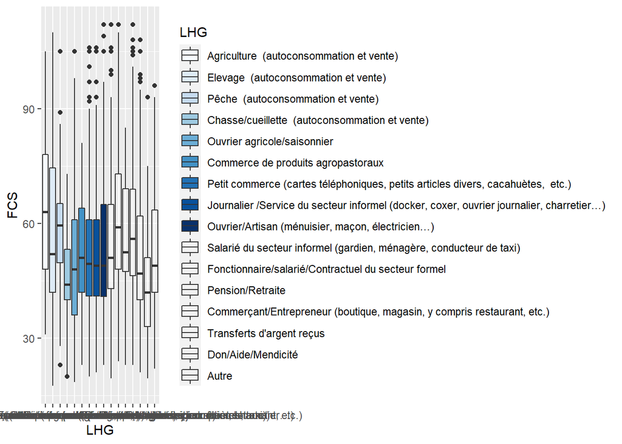

```r
a <- ggplot(fsms_juin_2015, aes(x = LHG, y = FCS))
a + geom_boxplot(aes(fill = LHG), width = 0.8,
    position = position_dodge(2)) +
  scale_fill_brewer()
```

4.2. FCS vs boutiques EMEL Juin 2015

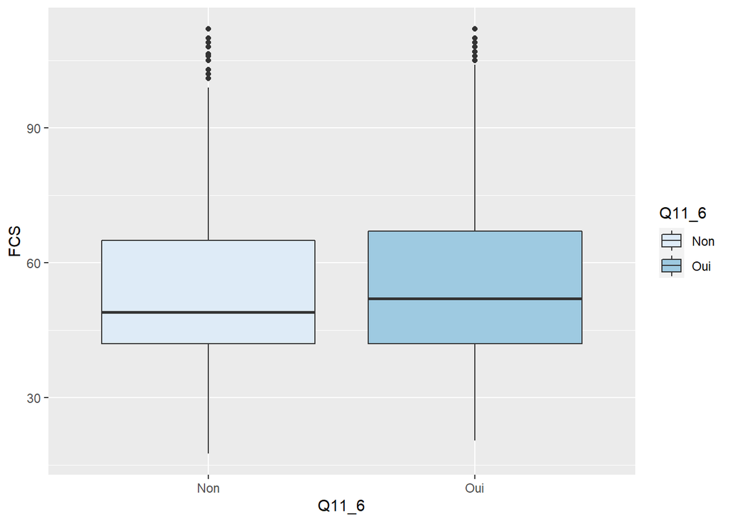

```r
a <- ggplot(fsms_juin_2015, aes(x = Q11_6, y = FCS))
a + geom_boxplot(aes(fill = Q11_6), width = 0.8,
    position = position_dodge(2)) +
  scale_fill_brewer()
```

4.3. FCS vs MILIEU Juin 2015

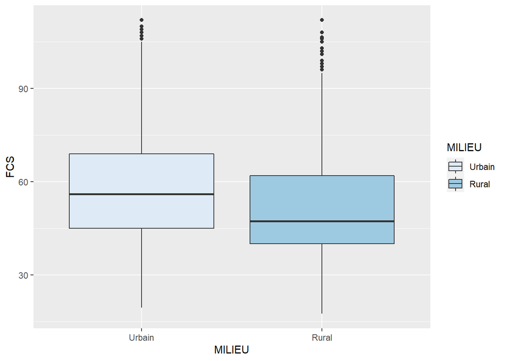

```r
a <- ggplot(fsms_juin_2015, aes(x = MILIEU, y = FCS))
a + geom_boxplot(aes(fill = MILIEU), width = 0.8,
    position = position_dodge(2)) +
  scale_fill_brewer()
```

4.4. FCS vs niveau d’éducation Juin 2015

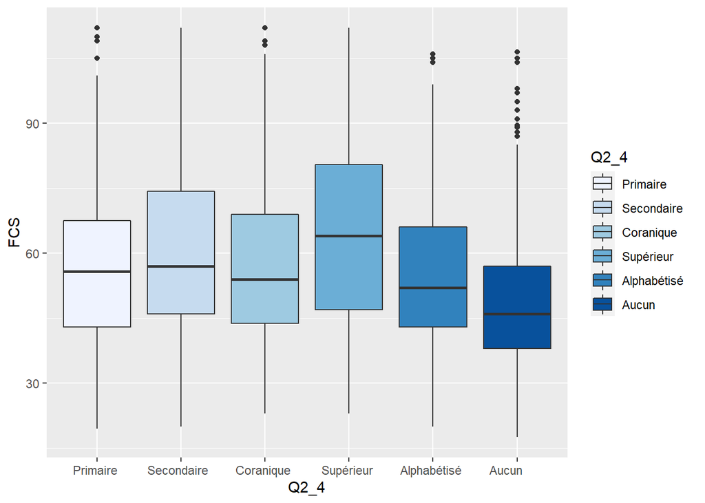

```r
a <- ggplot(fsms_juin_2015, aes(x = Q2_4, y = FCS))
a + geom_boxplot(aes(fill = Q2_4), width = 0.8,
    position = position_dodge(2)) +
  scale_fill_brewer()
```

4.5. FCS vs possession/exploitation de parcelle de terre cultivable Juin 2015

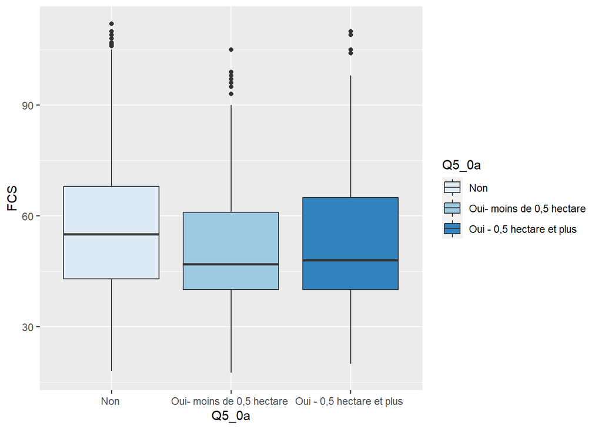

```r
a <- ggplot(fsms_juin_2015, aes(x = Q5_0a, y = FCS))
a + geom_boxplot(aes(fill = Q5_0a), width = 0.8,
    position = position_dodge(2)) +
  scale_fill_brewer()
```

4.6. FCS vs Boutiques de céréales Juin 2015

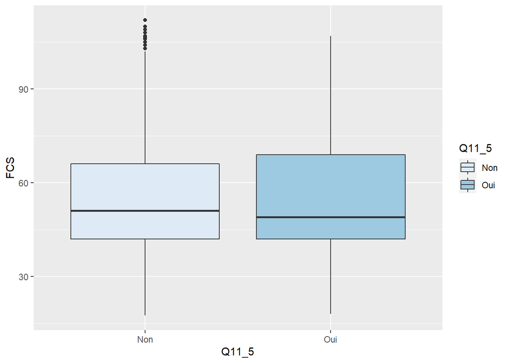

```r
a <- ggplot(fsms_juin_2015, aes(x = Q11_5, y = FCS))
a + geom_boxplot(aes(fill = Q11_5), width = 0.8,
    position = position_dodge(2)) +
  scale_fill_brewer()
```

4.7. Lait vs MILIEU Juin 2015

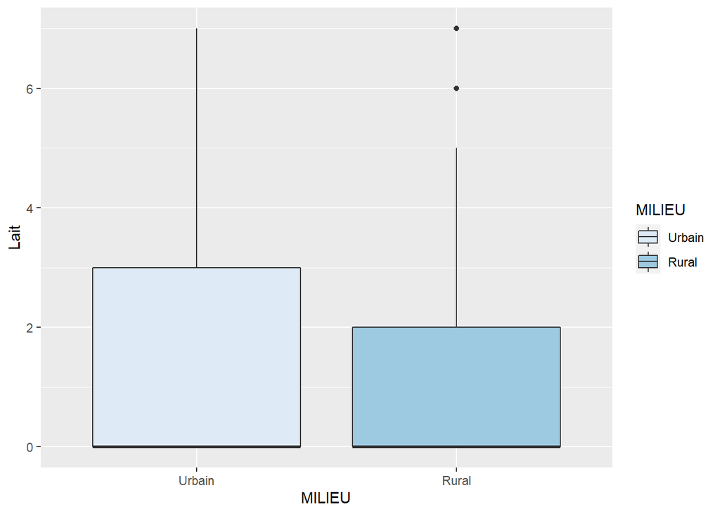

```r
a <- ggplot(fsms_juin_2015, aes(x = MILIEU, y = Lait))
a + geom_boxplot(aes(fill = MILIEU), width = 0.8,
    position = position_dodge(2)) +
  scale_fill_brewer()
```

4.8. Fruits vs MILIEU Juin 2015

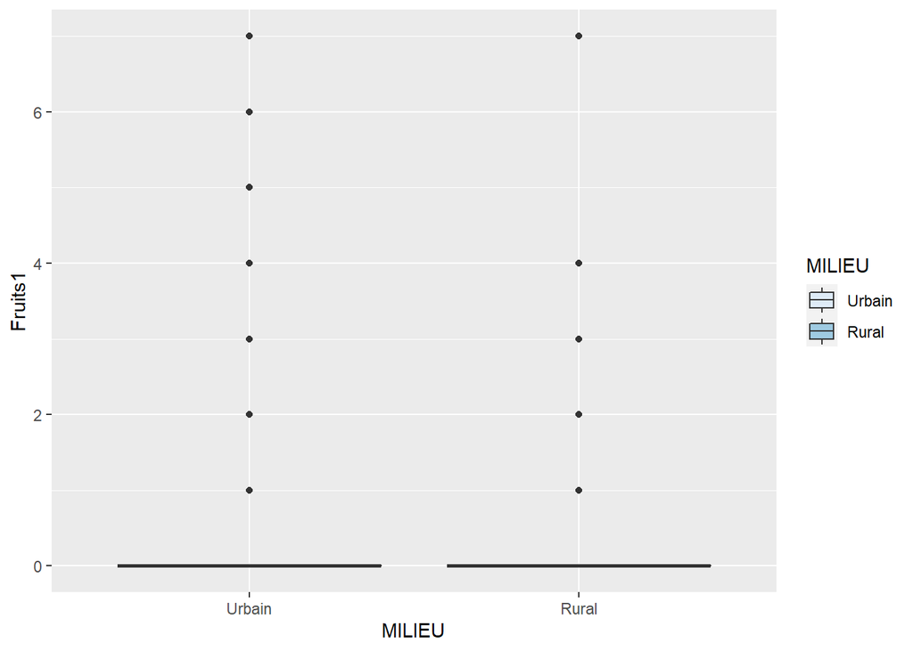

```r
a <- ggplot(fsms_juin_2015, aes(x = MILIEU, y = Fruits1))
a + geom_boxplot(aes(fill = MILIEU), width = 0.8,
    position = position_dodge(2)) +
  scale_fill_brewer()
```

4.9. Viande_poisson vs MILIEU Juin 2015

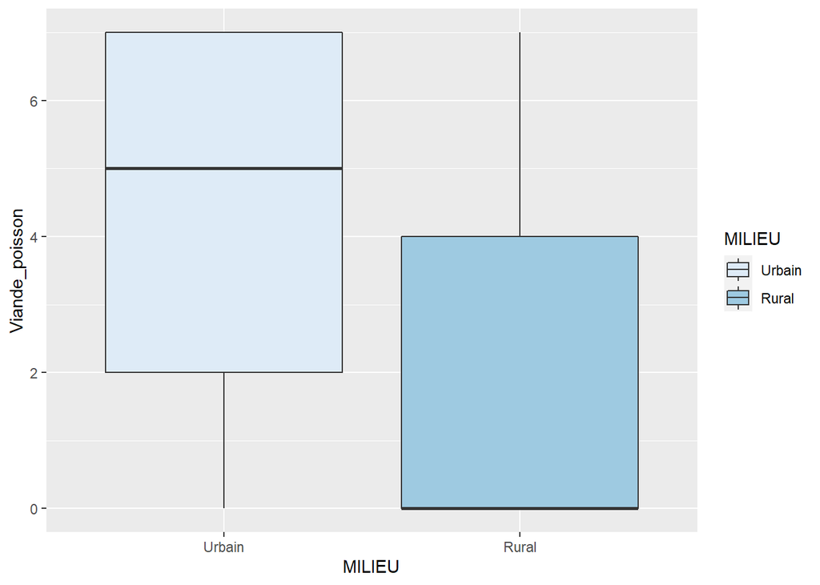

```r
a <- ggplot(fsms_juin_2015, aes(x = MILIEU, y = Viande_poisson))
a + geom_boxplot(aes(fill = MILIEU), width = 0.8,
    position = position_dodge(2)) +
  scale_fill_brewer()
```

4.10. Viande_poisson vs MILIEU Juin 2015

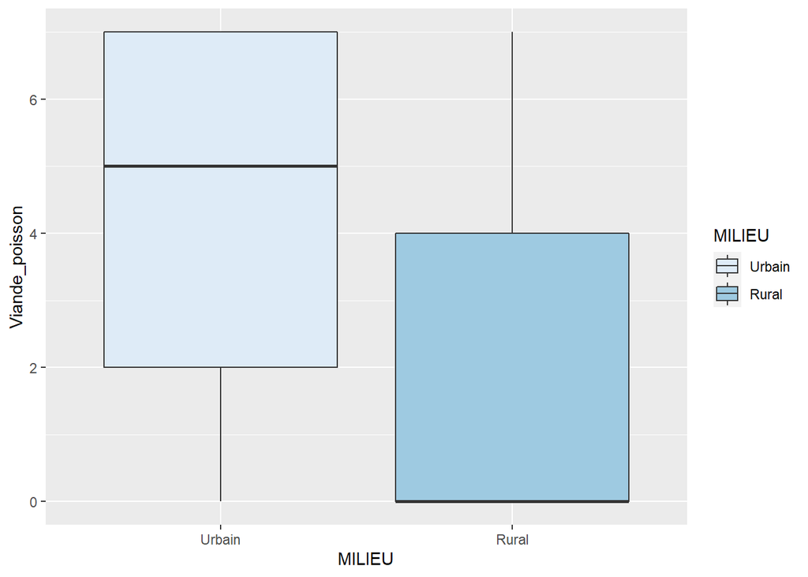

```r
a <- ggplot(fsms_juin_2015, aes(x = MILIEU, y = Viande_poisson))
a + geom_boxplot(aes(fill = MILIEU), width = 0.8,
    position = position_dodge(2)) +
  scale_fill_brewer()
```

Les données agrégées

Distibution des scores FCS par années

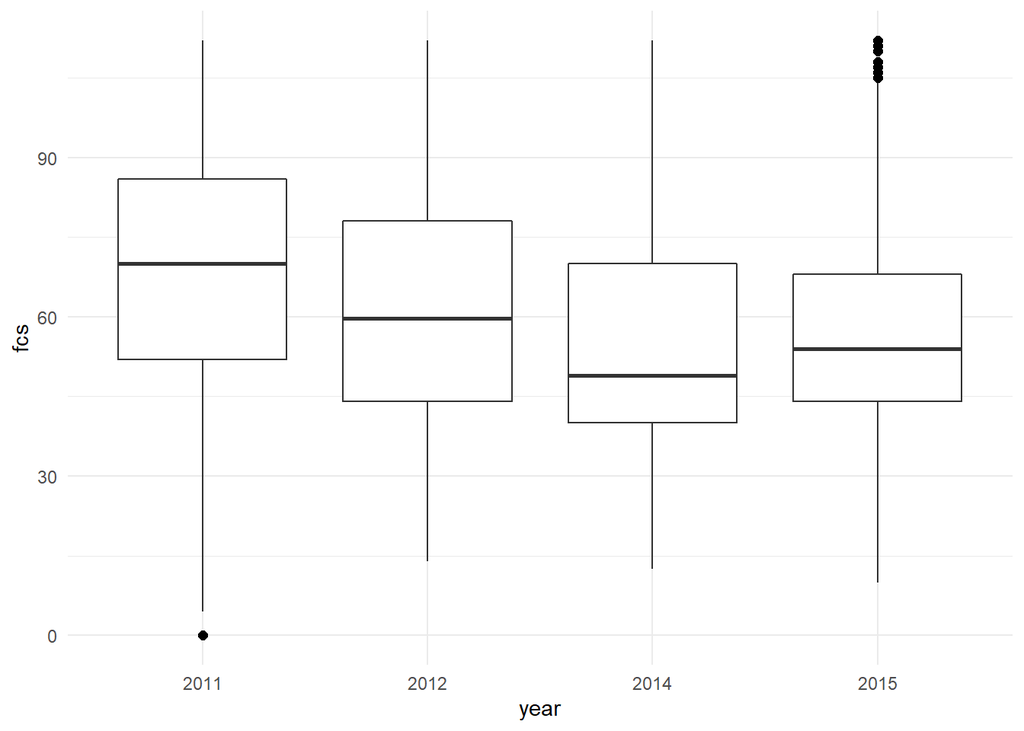

```r
aggregated_match_for_FSMS_files_with_yields_with_price$year <- as.factor(aggregated_match_for_FSMS_files_with_yields_with_price$year)
p1 <- ggplot(aggregated_match_for_FSMS_files_with_yields_with_price, aes(x=year, y=fcs)) +
    geom_boxplot(outlier.colour="black", outlier.shape=16,
             outlier.size=2, notch=FALSE)+ theme_minimal()
p1
```

Distibution des scores FCS par années / Milieu

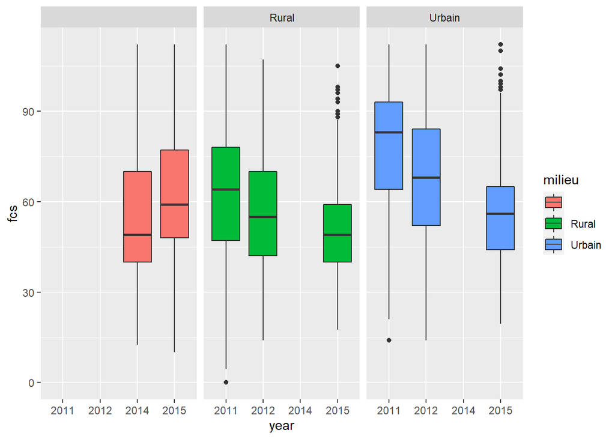

```r
p2 <- ggplot(aggregated_match_for_FSMS_files_with_yields_with_price, aes(x=year, y=fcs, fill=milieu)) +
    geom_boxplot() +
    facet_wrap(~milieu)
p2
```

Distibution des scores FCS par années / hors.nk

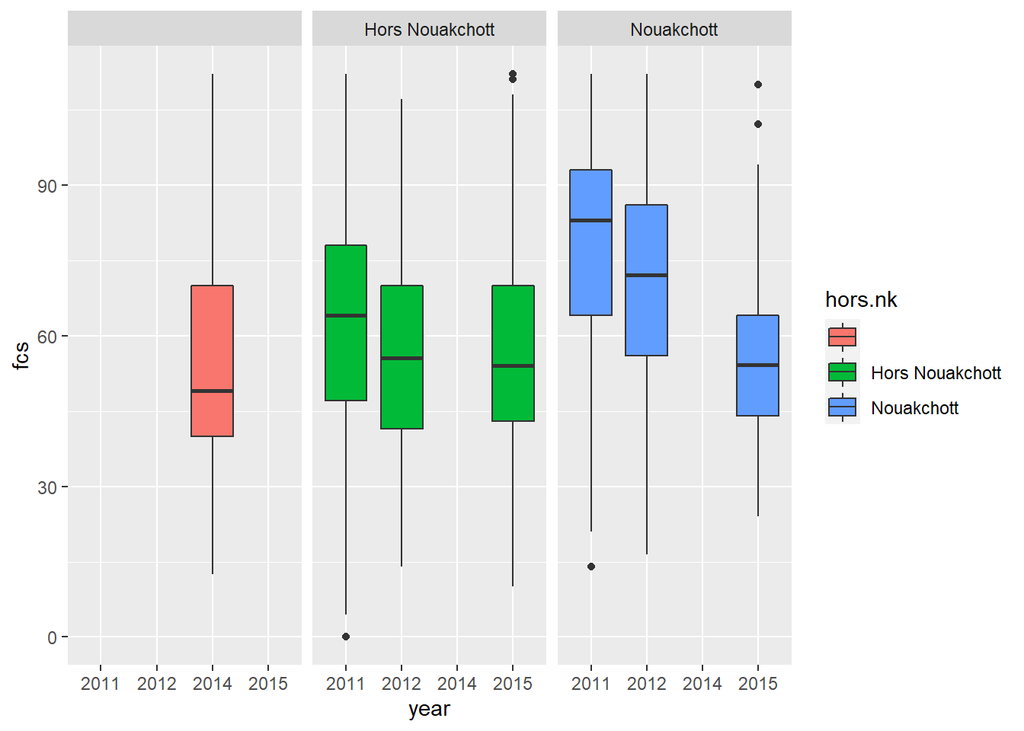

```r
p3 <- ggplot(aggregated_match_for_FSMS_files_with_yields_with_price, aes(x=year, y=fcs, fill=hors.nk)) +
    geom_boxplot() +
    facet_wrap(~hors.nk)
p3
```

Distibution des scores FCS par années / LHZ

[figure not shown]

```r
p4 <- ggplot(aggregated_match_for_FSMS_files_with_yields_with_price, aes(x=year, y=fcs, fill=LHZ)) +
    geom_boxplot() +
    facet_wrap(~LHZ)
p4
```

Distibution des scores FCS par années / wilaya

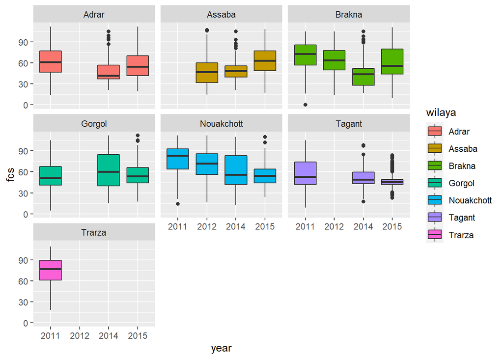

```r
p5 <- ggplot(aggregated_match_for_FSMS_files_with_yields_with_price, aes(x=year, y=fcs, fill=wilaya)) +
    geom_boxplot() +
    facet_wrap(~wilaya)
p5
```

Distibution des scores FCS par années / Q9_1 (Perte d’emploi/ Réduction ou Irrégularité des …)

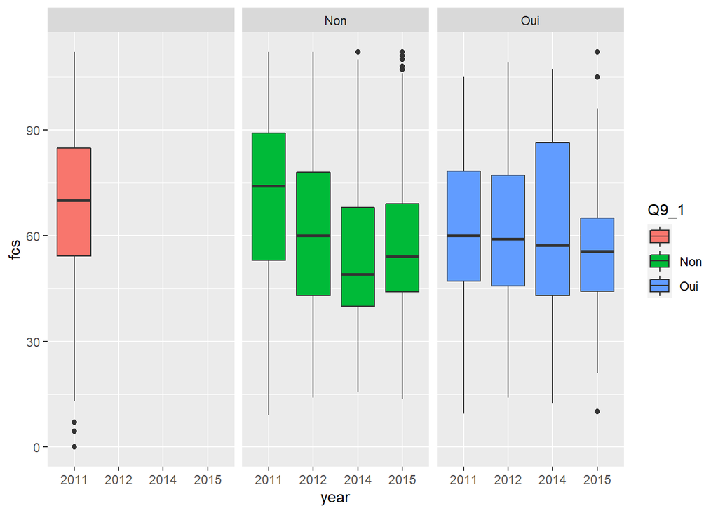

```r
p6 <- ggplot(aggregated_match_for_FSMS_files_with_yields_with_price, aes(x=year, y=fcs, fill=Q9_1)) +
    geom_boxplot() +
    facet_wrap(~Q9_1)
p6
```

Distibution des scores FCS par années / Q9_2 (Dépenses de santé/ Malade dans le ménage)

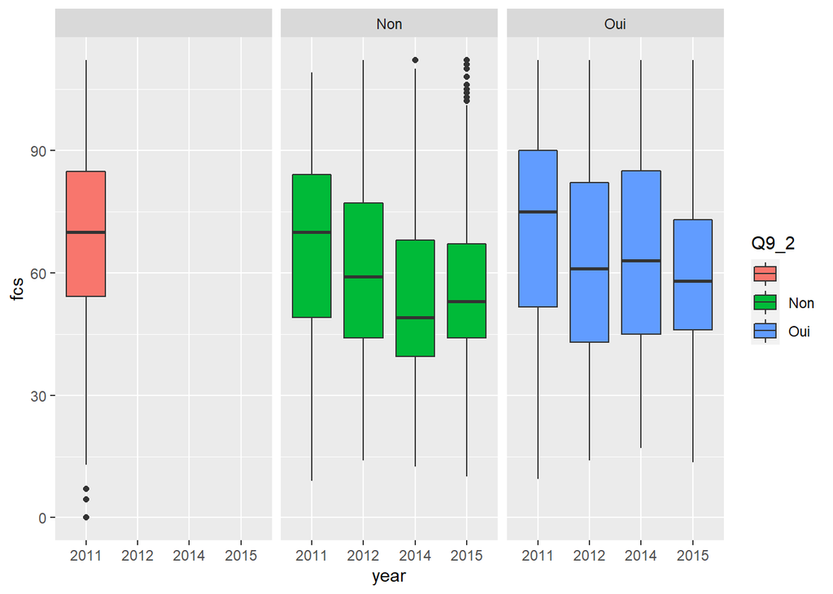

```r
p7 <- ggplot(aggregated_match_for_FSMS_files_with_yields_with_price, aes(x=year, y=fcs, fill=Q9_2)) +
    geom_boxplot() +
    facet_wrap(~Q9_2)
p7
```

Distibution des scores FCS par années / Q9_3 (Décès d’un membre de la famille, funérailles)

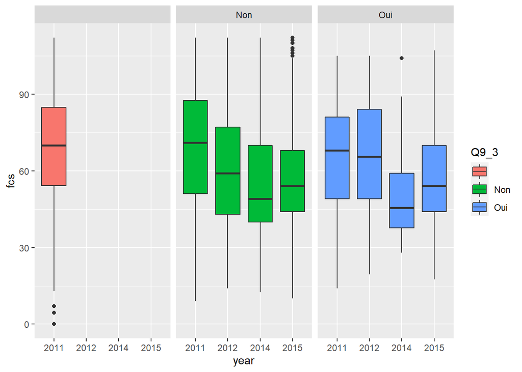

```r
p8 <- ggplot(aggregated_match_for_FSMS_files_with_yields_with_price, aes(x=year, y=fcs, fill=Q9_3)) +
    geom_boxplot() +
    facet_wrap(~Q9_3)
p8
```

Distibution des scores FCS par années / Q9_4 (Hausse des prix des denrées alimentaires)

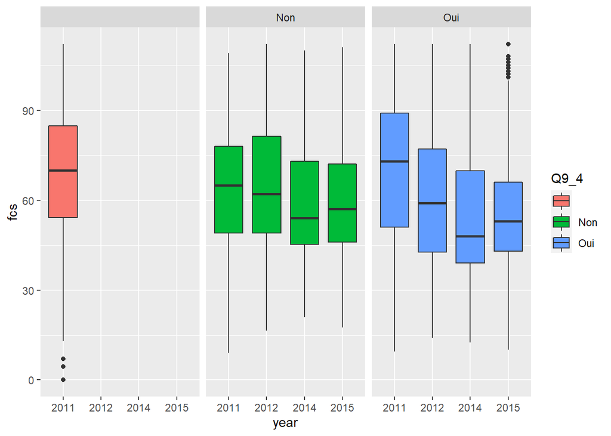

```r
p9 <- ggplot(aggregated_match_for_FSMS_files_with_yields_with_price, aes(x=year, y=fcs, fill=Q9_4)) +
    geom_boxplot() +
    facet_wrap(~Q9_4)
p9
```

Distibution des scores FCS par années / Q9_5 (Remboursement de dettes)

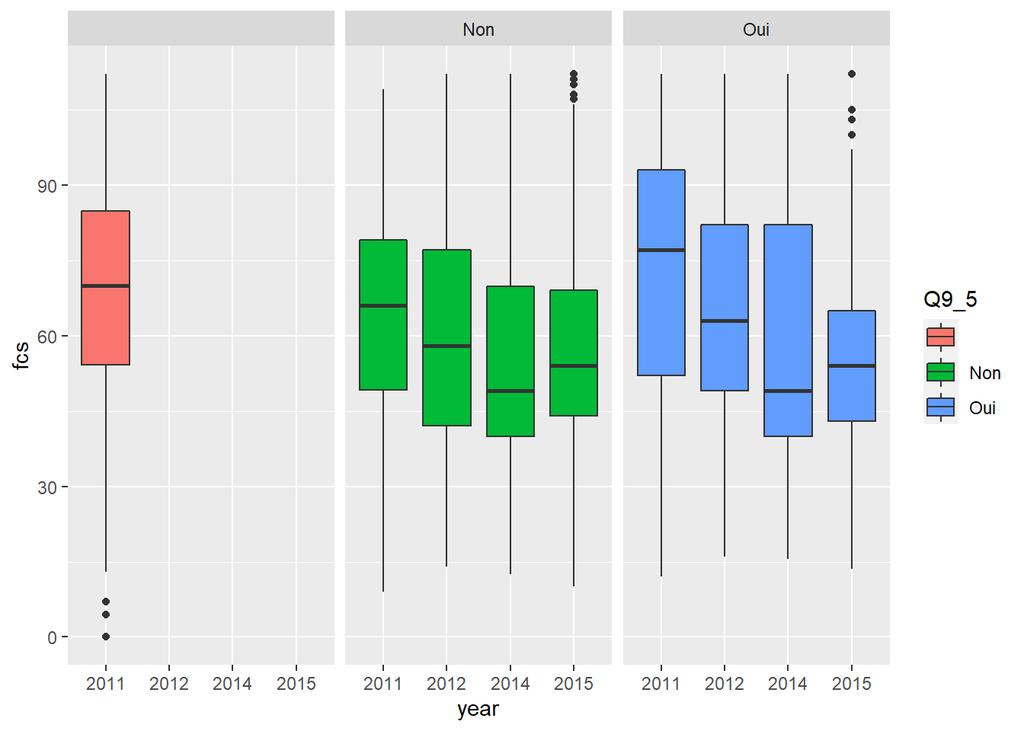

```r
p10 <- ggplot(aggregated_match_for_FSMS_files_with_yields_with_price, aes(x=year, y=fcs, fill=Q9_5)) +
    geom_boxplot() +
    facet_wrap(~Q9_5)
p10
```

Distibution des scores FCS par années / Q9_6 (Perte de bétail)

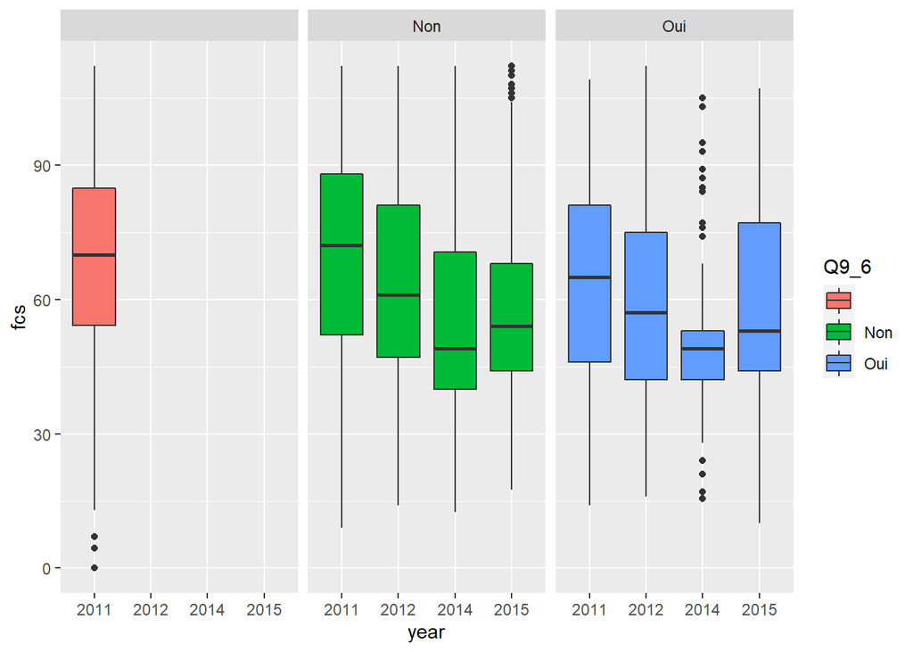

```r
p11 <- ggplot(aggregated_match_for_FSMS_files_with_yields_with_price, aes(x=year, y=fcs, fill=Q9_6)) +
    geom_boxplot() +
    facet_wrap(~Q9_6)
p11
```

Distribution des scores FCS par années / Q9_7 (Irrégularité /Insalubrité de l’eau de boisson)

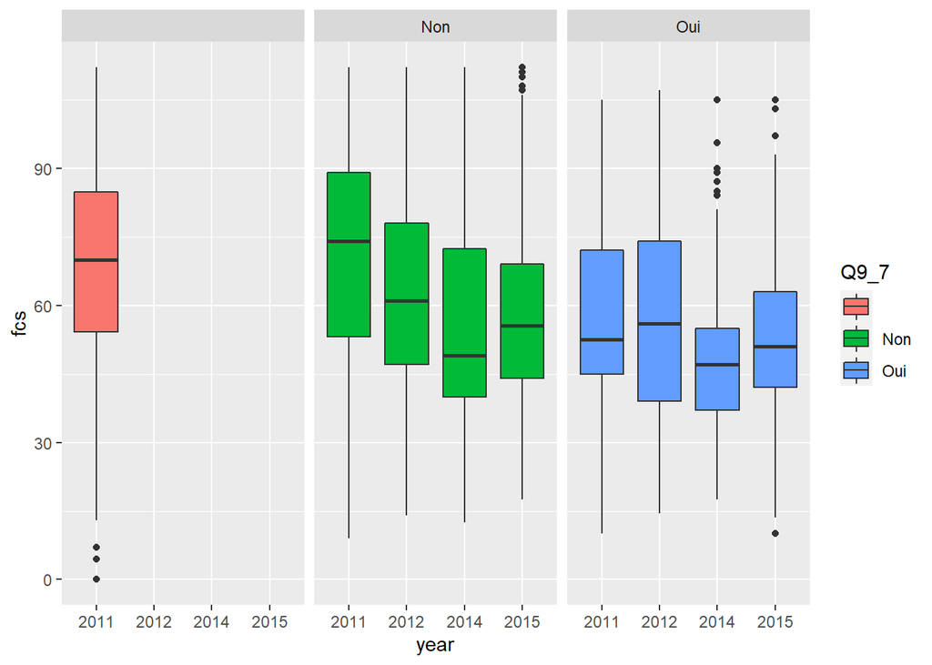

```r
p12 <- ggplot(aggregated_match_for_FSMS_files_with_yields_with_price, aes(x=year, y=fcs, fill=Q9_7)) +
    geom_boxplot() +
    facet_wrap(~Q9_7)
p12
```

Distribution des scores FCS par années / Q2_3 (Statut matrimonial)

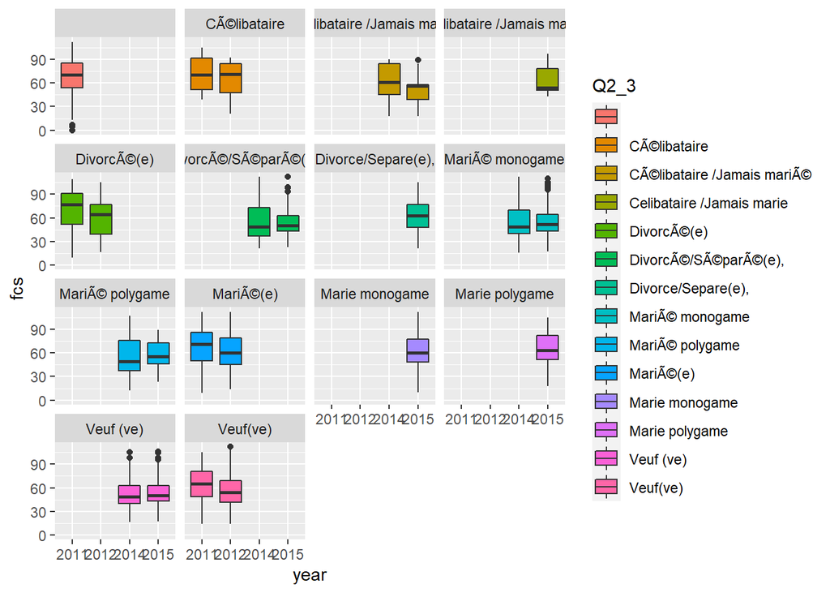

```r
p12 <- ggplot(aggregated_match_for_FSMS_files_with_yields_with_price, aes(x=year, y=fcs, fill=Q2_3)) +
    geom_boxplot() +
    facet_wrap(~Q2_3)
p12
```

Distibution des scores FCS par années / Q2_3 (Statut matrimonial)

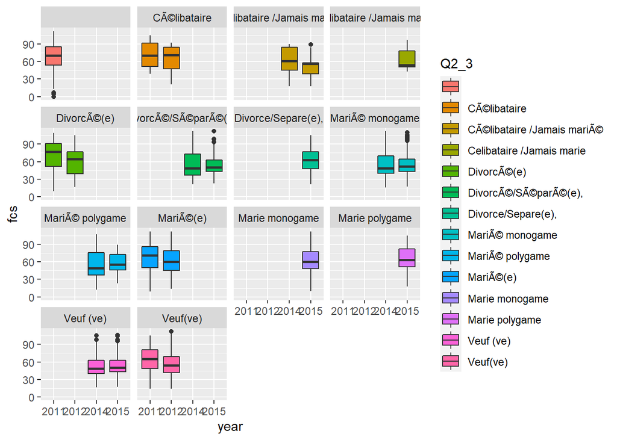

```r
p12 <- ggplot(aggregated_match_for_FSMS_files_with_yields_with_price, aes(x=year, y=fcs, fill=Q2_3)) +
    geom_boxplot() +
    facet_wrap(~Q2_3)
p12
```

Distibution des prix ‘Meat..beef….Retail’ par années / wilaya

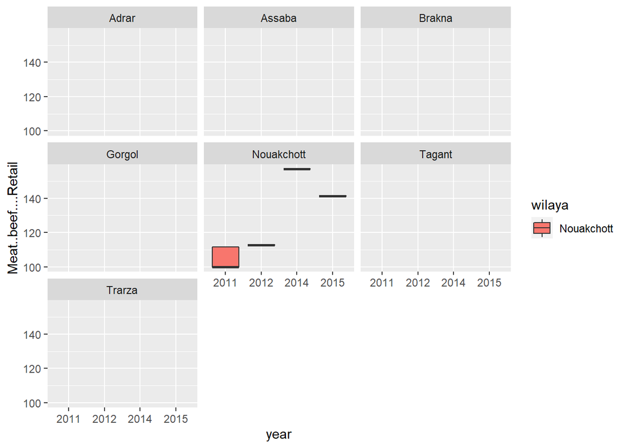

```r
p13 <- ggplot(aggregated_match_for_FSMS_files_with_yields_with_price, aes(x=year, y=Meat..beef....Retail, fill=wilaya)) +
    geom_boxplot() +
    facet_wrap(~wilaya)
p13
```

Distibution des prix ‘Meat..camel….Retail’ par années / wilaya

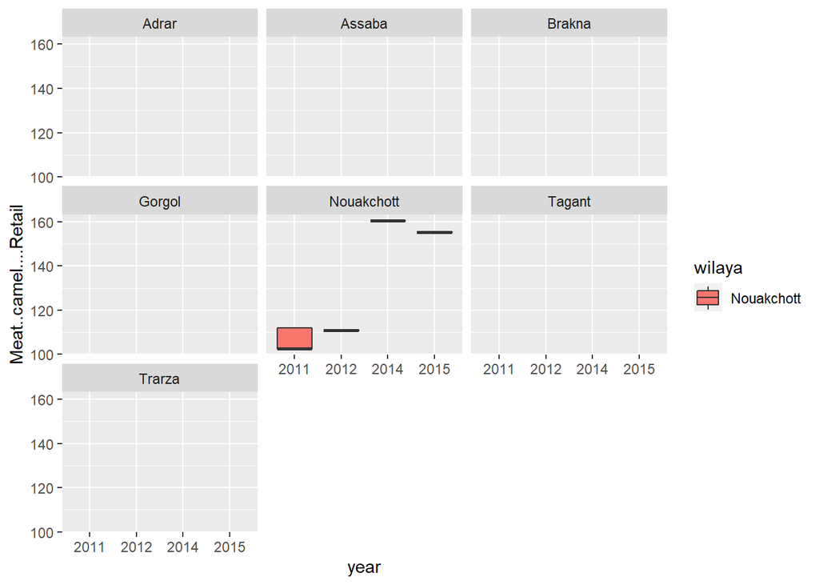

```r
p14 <- ggplot(aggregated_match_for_FSMS_files_with_yields_with_price, aes(x=year, y=Meat..camel....Retail, fill=wilaya)) +geom_boxplot() +
    facet_wrap(~wilaya)
p14
```

Distibution des prix ‘Milk..powder….Retail’ par années / wilaya

[figure not shown]

```r
p15 <- ggplot(aggregated_match_for_FSMS_files_with_yields_with_price, aes(x=year, y=Milk..powder....Retail, fill=wilaya)) +geom_boxplot() +
    facet_wrap(~wilaya)
p15
```

Distibution des prix ‘Sugar…Retail’ par années / wilaya

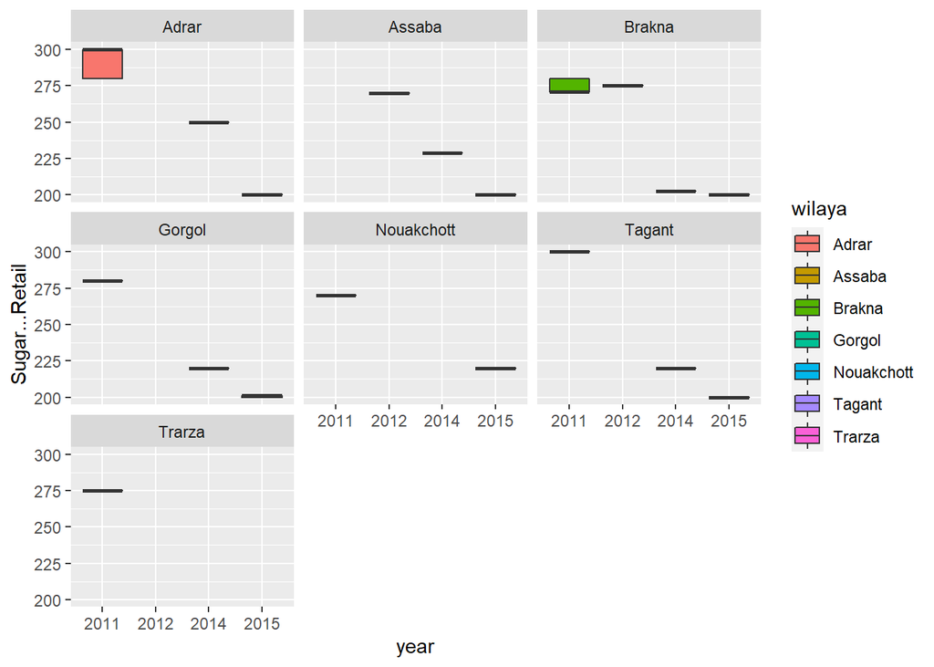

```r
p16 <- ggplot(aggregated_match_for_FSMS_files_with_yields_with_price, aes(x=year, y=Sugar...Retail, fill=wilaya)) +geom_boxplot() +
    facet_wrap(~wilaya)
p16
```

```r
#ajouter les variables mois et année
wfp_food_prices_mauritania$annee=substring(wfp_food_prices_mauritania$date,1,4)
wfp_food_prices_mauritania$mois=substring(wfp_food_prices_mauritania$date,6,7)



#cmname
table(wfp_food_prices_mauritania$cmname)
```

```
##
##                                  Beans (niebe) - Retail
##                                                     224
##                                       Couscous - Retail
##                                                     158
##                                   Feed (flour) - Retail
##                                                      71
##                                  Feed (rakhel) - Retail
##                                                      74
##                              Feed (wheat bran) - Retail
##                                                       4
##                              Livestock (camel) - Retail
##                                                      49
##                             Livestock (cattle) - Retail
##                                                      43
##            Livestock (goat, medium-sized male) - Retail
##                                                      78
## Livestock (sheep, medium-sized castrated male) - Retail
##                                                      71
##                                  Maize (local) - Retail
##                                                     169
##                                    Meat (beef) - Retail
##                                                     197
##                                   Meat (camel) - Retail
##                                                     197
##                                  Milk (powder) - Retail
##                                                     236
##                                         Millet - Retail
##                                                      93
##                                Oil (vegetable) - Retail
##                                                    1489
##                               Pasta (macaroni) - Retail
##                                                      92
##                                Rice (imported) - Retail
##                                                    1476
##                                   Rice (local) - Retail
##                                                    1314
##                               Sorghum (r'haya) - Retail
##                                                      12
##                                  Sorghum (red) - Retail
##                                                      26
##                             Sorghum (taghalit) - Retail
##                                                    1146
##                                          Straw - Retail
##                                                      24
##                                          Sugar - Retail
##                                                    1493
##                                          Wheat - Retail
##                                                    1301
##                                    Wheat flour - Retail
##                                                     288
##                                     Wheat meal - Retail
##                                                      79
```

```r
#category
table(wfp_food_prices_mauritania$category)
```

```
##
##  cereals and tubers meat, fish and eggs      milk and dairy  miscellaneous food
##                6154                 635                 236                1493
##            non-food        oil and fats     pulses and nuts
##                 173                1489                 224
```

```r
#admname
table(wfp_food_prices_mauritania$admname)
```

```
##
##              Adrar             Assaba             Brakna Dakhlet-Nouadhibou
##               1279               1023               1798                426
##             Gorgol         Guidimakha    Hodh Ech Chargi     Hodh El Gharbi
##                768                782                876                840
##         Nouakchott             Tagant      Tiris-Zemmour             Trarza
##               1466                390                 29                727
```

```r
#summary price data
price_summary=wfp_food_prices_mauritania %>%
  group_by(annee, admname, cmname) %>%
  summarise(mean_price=mean(price))
```

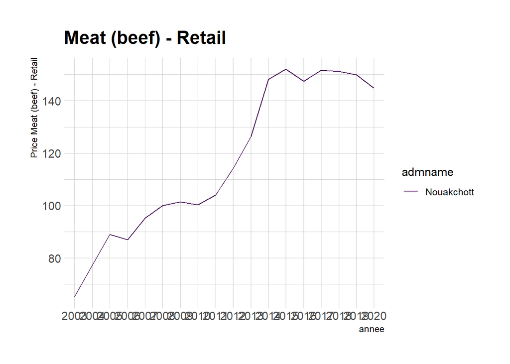

```r
#Meat (beef) - Retail
don <- price_summary %>%
  filter(cmname == 'Meat (beef) - Retail')
don %>%
  ggplot( aes(x=annee, y=mean_price, group=admname, color=admname)) +
  geom_line()+
  scale_color_viridis(discrete = TRUE) +
  ggtitle("Meat (beef) - Retail") +
  theme_ipsum() +
  ylab("Price Meat (beef) - Retail")
```

[output not shown]

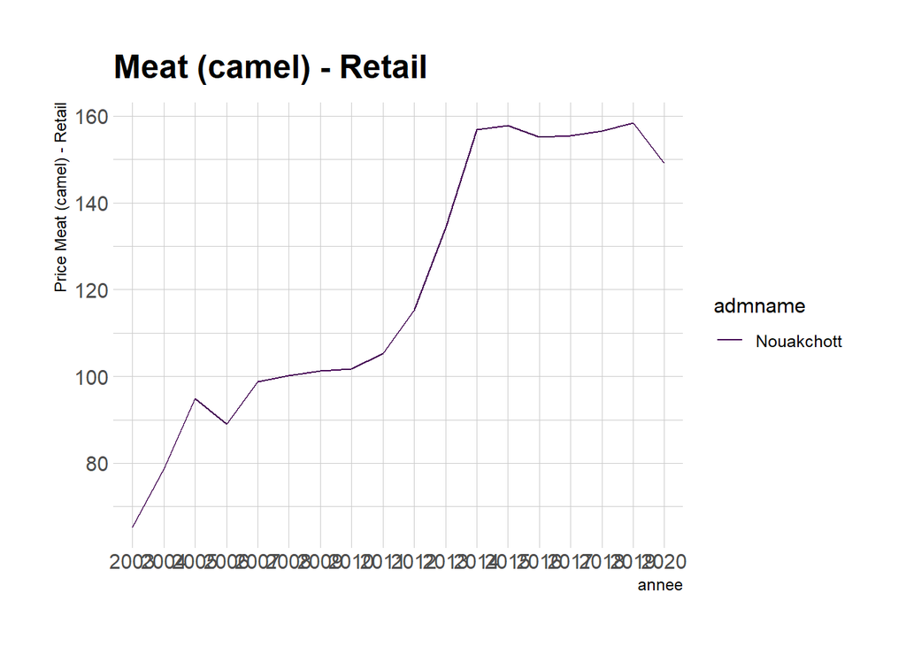

```r
  #Meat (camel) - Retail
  don <- price_summary %>%
    filter(cmname == 'Meat (camel) - Retail')
  don %>%
    ggplot( aes(x=annee, y=mean_price, group=admname, color=admname)) +
    geom_line()+
    scale_color_viridis(discrete = TRUE) +
    ggtitle("Meat (camel) - Retail") +
    theme_ipsum() +
    ylab("Price Meat (camel) - Retail")
```

[output not shown]

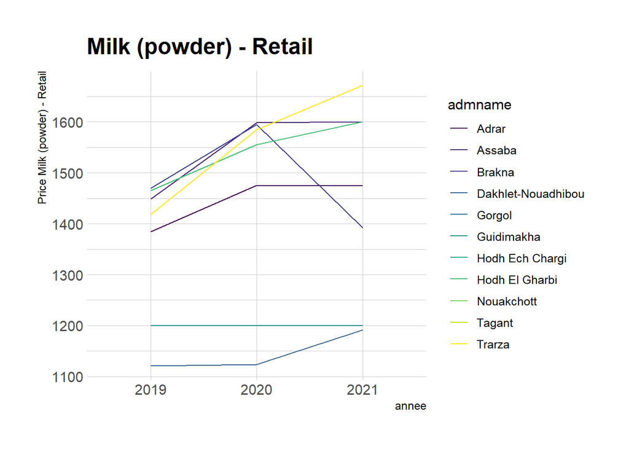

```r
  #Milk (powder) - Retail
  don <- price_summary %>%
    filter(cmname == 'Milk (powder) - Retail')
  don %>%
    ggplot( aes(x=annee, y=mean_price, group=admname, color=admname)) +
    geom_line()+
    scale_color_viridis(discrete = TRUE) +
    ggtitle("Milk (powder) - Retail") +
    theme_ipsum() +
    ylab("Price Milk (powder) - Retail")
```